# Composite Variables 2: Canonical Correlation, MANOVA, and DFA

## Hierarchy of GLMs

[figure not shown]

## Approaches to continuous data

*Correlation*:

- 2 interchangeable variables

*Canonical correlation*

- *p* Continuous ~ *q* Continuous

*PCA*:

- 0 outcome variables (`~ .`)
- *q* possibly correlated variables

*Multiple regression*:

- 1 continuous outcome variable
- *q* predictors

## Multivariate (Gaussian) linear models

Directional:

\[\mbox{Outcome variables} \sim \mbox{Predictor variables}\]

1. “MLM”: *p* Continuous ~ *q* Continuous
2. MANOVA and Hotelling’s *T*<sup>2</sup>: *p* Continuous ~ *q* Categorical
3. MANCOVA: *p* Continuous ~ *q* Categorical + *r* Continuous
4. (Multiple) correspondence analysis: *p* Categorical ~ *q* Categorical

All of these create composite variables.

## Canonical correlation

Correlations of *linear combinations* of a set of multiple continuous variables with a separate set of multiple continuous variables.

\[\mbox{Multiple variables} \sim \mbox{Multiple variables}\]

- Weather variables vs. Growth variables
- Ecology variables vs. Urbanization variables
- Diversity variables vs. Landscape variables

## Wheat

> “Two identical 13.6-ton (500 bu.) parcels of Manitoba Northern wheat, variety Selkirk, were stored 183 cm deep in 2 similar and adjoining 305 cm X 333 cm wooden bins in a granary in Winnipeg during 1959-67. Two hundred-gram samples were collected monthly from fixed sampling sites in the bins.” Sinha et al. (1969)

Measure biotic (insects, fungi, mites) and abiotic (location, depth, temperature) factors.

- How do these correlate?

## Wheat

[figure not shown]

## MANOVA

Morant (1923) published data on 32 skulls from Tibet:

```r
M <- read_excel("../data/Tibetan_Skulls.xlsx") %>%
  mutate(Origin = factor(Origin))
str(M)
```

```
## tibble [32 × 6] (S3: tbl_df/tbl/data.frame)
##  $ Skull_Length: num [1:32] 190 172 167 170 175 ...
##  $ Skull_Width : num [1:32] 152 132 130 150 138 ...
##  $ Skull_Height: num [1:32] 145 126 126 134 126 ...
##  $ Face_Height : num [1:32] 73.5 63 69.5 64.5 77.5 71.5 70.5 73.5 70 62 ...
##  $ Face_Breadth: num [1:32] 136 121 120 128 136 ...
##  $ Origin      : Factor w/ 2 levels "Khams","Sikkim": 2 2 2 2 2 2 2 2 2 2 ...
```

## Tibetan skulls

[figure not shown]

## Tibetan skulls

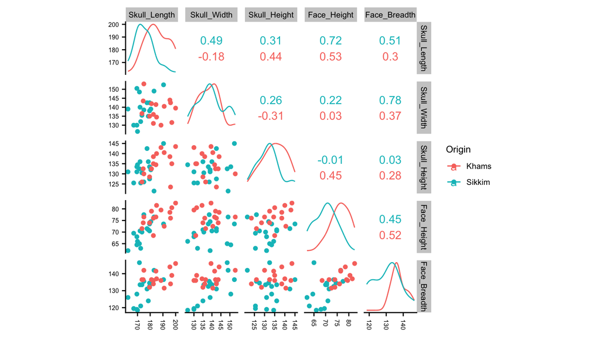

## MANOVA: Tibetan skulls

```r
fm <- lm(cbind(Skull_Length, Skull_Width,
               Skull_Height, Face_Height,
               Face_Breadth) ~ Origin, data = M)
Anova(fm, type = "III")
```

```
##
## Type III MANOVA Tests: Pillai test statistic
##             Df test stat approx F num Df den Df    Pr(>F)
## (Intercept)  1   0.99817  2832.58      5     26 < 2.2e-16 ***
## Origin       1   0.48188     4.84      5     26  0.002936 **
## ---
## Signif. codes:  0 '***' 0.001 '**' 0.01 '*' 0.05 '.' 0.1 ' ' 1
```

## MANOVA vs DFA & Logistic Regression

MANOVA and Hotelling’s *T*<sup>2</sup>: *p* Continuous ~ *q* Categorical

MANOVA creates a composite variable from the set of outcome variables and asks whether the groups differ.

- Predict the composite from the group membership

DFA & Logistic Regression: *q* Categorical ~ *p* Continuous and/or *r* Categorical

DFA and Logistic Regression create a composite variable from the set of predictor variables and asks which variables best predict group membership.

- Predict group membership from the composite scores

## Logistic regression vs. DFA

Both:

- Which variable(s) are good predictors of group membership
- Groups are known *a priori*
- Uses linear combinations of variables
- **Predict new observations**

Differences:

- Some assumptions
- Predictive ability (depends on specifics)
- See: [this stackexchange](https://stats.stackexchange.com/questions/95247/logistic-regression-vs-lda-as-two-class-classifiers)
- Ease of interpretation for different questions

## Penguin data

```r
library(palmerpenguins)
glimpse(penguins)
```

```
## Rows: 344
## Columns: 8
## $ species           <fct> Adelie, Adelie, Adelie, Adelie, Adelie, Adelie, Adel…
## $ island            <fct> Torgersen, Torgersen, Torgersen, Torgersen, Torgerse…
## $ bill_length_mm    <dbl> 39.1, 39.5, 40.3, NA, 36.7, 39.3, 38.9, 39.2, 34.1, …
## $ bill_depth_mm     <dbl> 18.7, 17.4, 18.0, NA, 19.3, 20.6, 17.8, 19.6, 18.1, …
## $ flipper_length_mm <int> 181, 186, 195, NA, 193, 190, 181, 195, 193, 190, 186…
## $ body_mass_g       <int> 3750, 3800, 3250, NA, 3450, 3650, 3625, 4675, 3475, …
## $ sex               <fct> male, female, female, NA, female, male, female, male…
## $ year              <int> 2007, 2007, 2007, 2007, 2007, 2007, 2007, 2007, 2007…
```

```r
penguins <- penguins %>%
  dplyr::select(species, bill_length_mm, bill_depth_mm,
         flipper_length_mm, body_mass_g) %>%
  drop_na()
```

## Penguin data

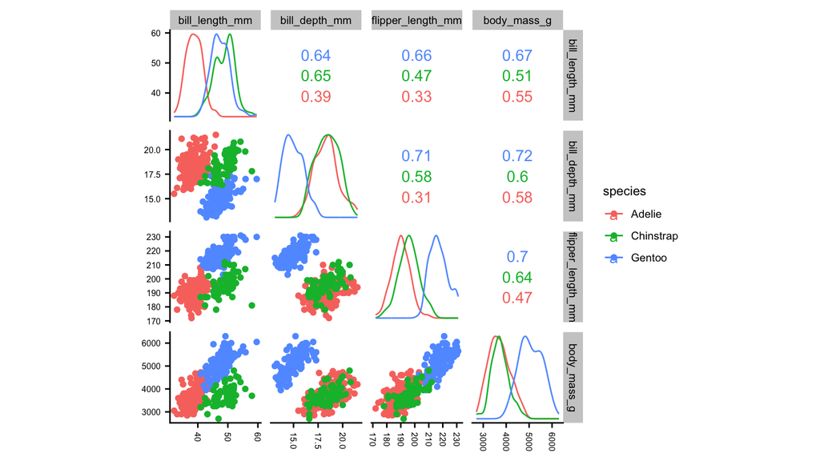

## DFA in R

Linear discriminant analysis:

- `lda()` with `Group ~ Predictors`

```r
penguin_lda <- lda(species ~ bill_length_mm + bill_depth_mm +
                     flipper_length_mm + body_mass_g,
                   data = penguins)
```

## Posterior prediction

```r
penguin_predict <- predict(penguin_lda, penguins[, 2:5])
penguin_predict$posterior %>% head(10)
```

```
##       Adelie    Chinstrap       Gentoo
## 1  0.9999774 2.264127e-05 5.065367e-20
## 2  0.9997245 2.755161e-04 3.556988e-13
## 3  0.9840412 1.595884e-02 1.531394e-14
## 4  0.9999987 1.305680e-06 5.962671e-21
## 5  0.9999922 7.755865e-06 1.004313e-24
## 6  0.9999009 9.905930e-05 3.105869e-17
## 7  0.9999998 1.623133e-07 3.027708e-15
## 8  1.0000000 4.970052e-08 1.472592e-17
## 9  0.9999208 7.922423e-05 1.819785e-19
## 10 0.9997504 2.496310e-04 6.621319e-15
```

## Classification

```r
(penguin_classify <- penguin_predict$class)
```

```
##   [1] Adelie    Adelie    Adelie    Adelie    Adelie    Adelie    Adelie
##   [8] Adelie    Adelie    Adelie    Adelie    Adelie    Adelie    Adelie
##  [15] Adelie    Adelie    Adelie    Adelie    Adelie    Adelie    Adelie
##  [22] Adelie    Adelie    Adelie    Adelie    Adelie    Adelie    Adelie
##  [29] Adelie    Adelie    Adelie    Adelie    Adelie    Adelie    Adelie
##  [36] Adelie    Adelie    Adelie    Adelie    Adelie    Adelie    Adelie
##  [43] Adelie    Adelie    Adelie    Adelie    Adelie    Adelie    Adelie
##  [50] Adelie    Adelie    Adelie    Adelie    Adelie    Adelie    Adelie
##  [57] Adelie    Adelie    Adelie    Adelie    Adelie    Adelie    Adelie
##  [64] Adelie    Adelie    Adelie    Adelie    Adelie    Adelie    Adelie
##  [71] Adelie    Adelie    Chinstrap Adelie    Adelie    Adelie    Adelie
##  [78] Adelie    Adelie    Adelie    Adelie    Adelie    Adelie    Adelie
##  [85] Adelie    Adelie    Adelie    Adelie    Adelie    Adelie    Adelie
##  [92] Adelie    Adelie    Adelie    Adelie    Adelie    Adelie    Adelie
##  [99] Adelie    Adelie    Adelie    Adelie    Adelie    Adelie    Adelie
```

[output cut: 35 more lines]

## Percent correct

Mean value of the correct classifications

```r
mean(penguin_classify == penguins$species)
```

```
## [1] 0.9883041
```

## Confusion matrix

```r
table(Original = penguins$species, Predicted = penguin_classify)
```

```
##            Predicted
## Original    Adelie Chinstrap Gentoo
##   Adelie       150         1      0
##   Chinstrap      3        65      0
##   Gentoo         0         0    123
```

## Predicting a new observation

```r
new_penguin <- tibble(bill_length_mm = 45,
                      bill_depth_mm = 15,
                      flipper_length_mm = 220,
                      body_mass_g = 5000)
```

## Predicting a new observation

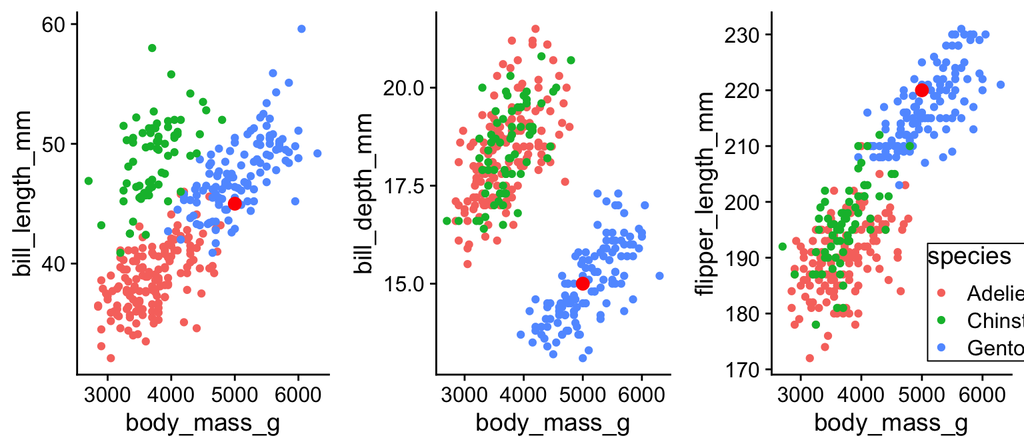

```r
predict(penguin_lda, new_penguin)$posterior
```

```
##        Adelie    Chinstrap Gentoo
## 1 2.17789e-15 5.180976e-15      1
```

## Predicting a new observation

```r
new_penguin <- tibble(bill_length_mm = 40,
                      bill_depth_mm = 12,
                      flipper_length_mm = 150,
                      body_mass_g = 2500)
```

## Predicting a new observation

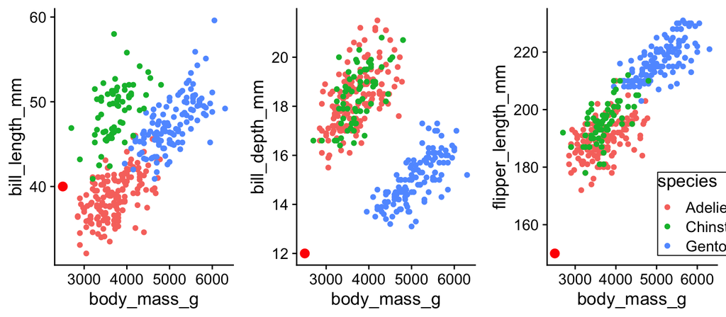

```r
predict(penguin_lda, new_penguin)$posterior
```

```
##       Adelie Chinstrap       Gentoo
## 1 0.01257576 0.9874242 6.313066e-11
```

## References

Morant, G. M. 1923. A First Study of the Tibetan Skull. *Biometrika* 14:193–260.

Sinha, R. N., H. A. H. Wallace, and F. S. Chebib. 1969. Canonical Correlation Between Groups of Acarine, Fungal and Environmental Variables in Bulk Grain Ecosystems. *Research in Population Ecology* 11:92–104.